# WGCNA on Breast Cancer data

by: Lan YANG

2023-10-01

**Weighted Gene Co-expression Network Analysis (WGCNA)** is a system biology approach dedicated to identifyong correlation patterns between features in a set of samples. In most cases, it is applied on gene expression data to find clusters (called modules) of highly correlated genes.

WGCNA builds a co-expressed gene network:

each node corresponds to a gene  
two genes are connected by an edge if their expression are considered as significantly correlated  
it’s an undirected network

WGCNA is the most famous approach to create gene co-expression networks.

**My libraries and versions in WGCNA:**

```r
R.version.string
```

```
## [1] "R version 4.3.1 (2023-06-16 ucrt)"
```

```r
packageVersion("rmarkdown")
```

```
## [1] '2.25'
```

```r
packageVersion("knitr")
```

```
## [1] '1.44'
```

```r
packageVersion("rmdformats")
```

```
## [1] '1.0.4'
```

```r
packageVersion("bookdown")
```

```
## [1] '0.35'
```

```r
packageVersion("kableExtra")
```

```
## [1] '1.3.4'
```

```r
packageVersion("WGCNA")
```

```
## [1] '1.72.1'
```

```r
packageVersion("pheatmap")
```

```
## [1] '1.0.12'
```

```r
library("WGCNA")
library("pheatmap")
```

# Biological context

The Cancer Genome Atlas (TCGA) is a cancer genomic project that catalogs cancer-associated genomics profiles with several approaches (e.g. gene expression, copy number variation, DNA methylation, etc.).

We choose to use expression genes data from breast cancer. Some clinical information are available too, as subtype of cancer, gender and so on. These are considered as metadata.

The objective is to build a co-expression network using expression data, identify modules of tighly co-expressed genes, and relate them to clinical metadata.

# Input data

## Loading expression data

**Objective:** Load gene expression data from a CSV file and select a subset of rows and columns.  
**Data loaded:** The file “TCGA_Breast_mrna.csv” contains the expression data of different patient with breast cancer.  
**Commands:** **read.table()** function to read the CSV file and store its contents in a data frame named *exprData*. The first row of the CSV file contains column headers and the first column should be used as row names.  
**Outputs:** Data is composed of 2000 genes(in rows) and 379 patients(in columns). To show the first 5 rows and the first 5 columns of the exprData data frame.

```r
exprData <- read.table(file = "TCGA_Breast_mibiomics/TCGA_Breast_mrna.csv",
                       head = TRUE, row.names = 1, sep = ",")
exprData[c(1:5), c(1:5)]
```

```
##              A0SH      A0SJ     A0SK     A0SO      A04N
## STC2     6.809810  9.802976 5.495795 2.926594 11.579173
## LOC96610 7.139342  9.538014 7.440094 8.674870  8.457158
## APOD     6.399172 10.667394 1.722198 4.771886  6.579026
## FADS2    5.316216  5.537015 8.555220 8.911656  6.459865
## RPL9     5.916535  3.204786 6.702598 6.122295  3.572641
```

**Objective:** To transpose *exprData* using **t()** and then select a subset of rows and columns from the transposed data frame.  
**Outputs:** To be 2000 columns(genes) and 379 row s(patients).

```r
exprData <- t(exprData)
exprData[c(1:5), c(1:5)]
```

```
##           STC2 LOC96610      APOD    FADS2     RPL9
## A0SH  6.809810 7.139342  6.399172 5.316216 5.916535
## A0SJ  9.802976 9.538014 10.667394 5.537015 3.204786
## A0SK  5.495795 7.440094  1.722198 8.555220 6.702598
## A0SO  2.926594 8.674870  4.771886 8.911656 6.122295
## A04N 11.579173 8.457158  6.579026 6.459865 3.572641
```

## Removing missing values

**Objective:** This command creates a hierarchical cluster tree using the **hclust()** function. The *d* parameter specifies the distance matrix, which is calculated using the **dist()** function applied to the *exprData* to calculate the Euclidean distance among rows. The method parameter specifies the agglomeration method, which is set to “average”.  
**Data loaded:** Transposed *exprData*.

```r
patientsTree <- hclust(d = dist(exprData), method = "average")
```

**Objective:** draw a hierarchical clustering dendrogram and add a horizontal red line to the plot at y = 95.  
**Data loaded:** the hierarchical cluster tree *patientsTree*.  
**Outputs:** dendrogram with a red line at y = 95.  
**Plot**：the red line is used to identify outliers by a cut height to 95.in the plot, two patients seem to be outliers which can be removed in the next lines.

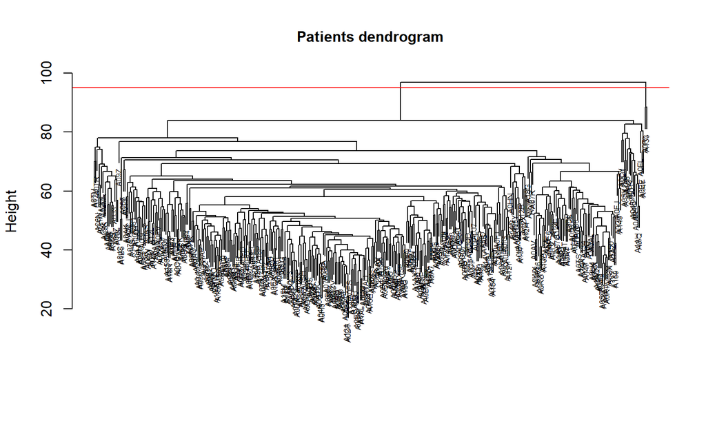

```r
plot(patientsTree, main = "Patients dendrogram", sub = "", xlab = "", cex.lab = 1, cex.axis = 1, cex.main = 1, cex = 0.5)
abline(h = 95, col = "red")
```

**Objective:** use **cutreeStatic()** function to cut the 2 outliers and **table()** function is used to display the counts of patients in each group.  
**Data loaded:** Patients dendrogram *patientsTree*.  
**Outputs:** summary of observations for each groups(The number that’s cut off and the number that’s left). we have 377 patients left after cutting.

```r
clust <- cutreeStatic(patientsTree, cutHeight = 95, minSize = 10)
table(clust)
```

```
## clust
##   0   1
##   2 377
```

**Objective:** to keep only patients that are in the second groups.  
**Commands:** subsets the exprData data frame, keeping only the rows (patients)in the second groups, assigns the number of columns (genes) and the number of rows(patients) in the filtered data frame to the variables for subsequent use.

```r
keepPatients <- clust == 1
exprData <- exprData[keepPatients,]
nGenes <- ncol(exprData)
nPatients <- nrow(exprData)
exprData[c(1:5), c(1:5)]
```

```
##           STC2 LOC96610      APOD    FADS2     RPL9
## A0SH  6.809810 7.139342  6.399172 5.316216 5.916535
## A0SJ  9.802976 9.538014 10.667394 5.537015 3.204786
## A0SK  5.495795 7.440094  1.722198 8.555220 6.702598
## A0SO  2.926594 8.674870  4.771886 8.911656 6.122295
## A04N 11.579173 8.457158  6.579026 6.459865 3.572641
```

## Clinical data

**Objective:** Load gene clinical data from a CSV file.  
**Data loaded:** The file “TCGA_Breast_clinical.csv” contains clinical metadata information for every patient/sample.  
**Commands:** **read.table()** function to read the CSV file and store its contents in a data frame named *clinicalTCGA*.  
**Outputs:** Data is composed of 377 patients(in rows) and 5 features(in columns).

```r
clinicalTCGA <- read.table(file = "TCGA_Breast_mibiomics/TCGA_Breast_clinical.csv",
                           sep = ",", head = TRUE, stringsAsFactors = TRUE)
```

**Objective:** show the head rows of the table.

```r
head(clinicalTCGA)
```

```
##   PatientIDs AgeDiagnosis           AnatomicNeoplasm Gender VitalStatus Subtype
## 1       A0SH           39  left upper inner quadrant female       alive    LumA
## 2       A0SJ           39                       left female       alive    LumA
## 3       A0SK           54 right upper outer quadrant female        dead   Basal
## 4       A0SO           67                      right female       alive   Basal
## 5       A04N           66                      right female       alive    LumA
## 6       A04P           36                       left female        dead   Basal
```

**Objective:** extract the clinicalTCGA data frame the clinical data and that the patient IDs are stored in the PatientIDs column.  
**Commands:** **match(patients, clinicalTCGA$PatientIDs)** matches the patient IDs in the patients vector with the corresponding patient IDs. Then exclude the first column (patient IDs). The resulting subset, containing the clinical data for the matched patients, is assigned to the *clinicalData* data frame.  
**Outputs:** data frame **clinicalData** with patient IDs as row names and 5 features as columns. Show the head rows of the table **clinicalData**.

```r
patients <- row.names(exprData)
clinicalRows <- match(patients, clinicalTCGA$PatientIDs)
clinicalData <- clinicalTCGA[clinicalRows, -1]
rownames(clinicalData) <- clinicalTCGA[clinicalRows, 1]
head(clinicalData)
```

```
##      AgeDiagnosis           AnatomicNeoplasm Gender VitalStatus Subtype
## A0SH           39  left upper inner quadrant female       alive    LumA
## A0SJ           39                       left female       alive    LumA
## A0SK           54 right upper outer quadrant female        dead   Basal
## A0SO           67                      right female       alive   Basal
## A04N           66                      right female       alive    LumA
## A04P           36                       left female        dead   Basal
```

**Objective:** map clustering results to patient traits, that is to recluster the newly built **exprData** with 377 patients and colored them with the 5 features. To  
**Outputs:** a newly tree with color bands of patients’ features below it.

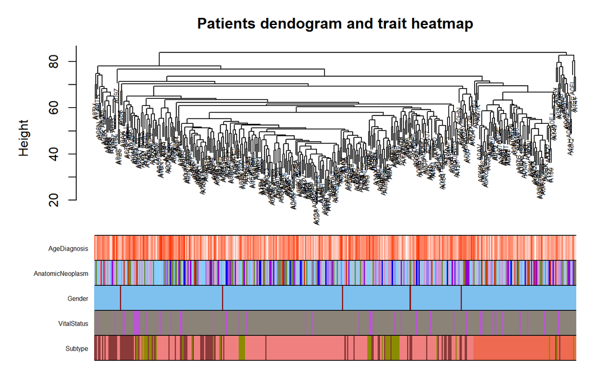

```r
patientsTree2 <- hclust(d = dist(exprData), method = "average")
traitColors <- labels2colors(clinicalData)
traitColors[,1] <- numbers2colors(clinicalData[1])
plotDendroAndColors(dendro = patientsTree2, colors = traitColors, groupLabels = names(clinicalData),
                    main = "Patients dendogram and trait heatmap",cex.dendroLabels = 0.5, cex.colorLabels = 0.5)
```

# Construction of the gene co-expression network

## Power selection

**Objective:** Create an even vector of 1-20.

```r
powers <- c(c(1:10), seq(from = 12, to = 20, by = 2))
powers
```

```
##  [1]  1  2  3  4  5  6  7  8  9 10 12 14 16 18 20
```

**Objective:** to select an appropriate soft threshold for network analysis.  
**Commands:** calculate the connectivity for given powers using the **pickSoftThreshold** function. Verbose is set to 5, which means that the function will display detailed information during the calculation.  
**Outputs:** a table **sft** of different powers.  
**Interpretation:** it calculates various network measurements for different power values and helps determine a suitable power value for constructing the network.

```r
sft <- pickSoftThreshold(exprData, powerVector = powers, verbose = 5)
```

```
## pickSoftThreshold: will use block size 2000.
##  pickSoftThreshold: calculating connectivity for given powers...
##    ..working on genes 1 through 2000 of 2000
##    Power SFT.R.sq   slope truncated.R.sq mean.k. median.k. max.k.
## 1      1 0.000701 -0.0702          0.779 340.000  3.49e+02 581.00
## 2      2 0.286000 -1.1900          0.771  95.900  9.33e+01 239.00
## 3      3 0.688000 -1.0100          0.951  36.000  3.04e+01 117.00
## 4      4 0.825000 -1.4400          0.984  16.600  1.12e+01  84.20
## 5      5 0.890000 -1.5500          0.988   8.860  4.54e+00  65.20
## 6      6 0.929000 -1.5700          0.992   5.290  1.95e+00  52.70
## 7      7 0.941000 -1.5500          0.988   3.430  8.92e-01  43.80
## 8      8 0.947000 -1.5000          0.990   2.370  4.27e-01  37.00
## 9      9 0.949000 -1.4500          0.991   1.720  2.19e-01  31.80
## 10    10 0.939000 -1.4400          0.986   1.290  1.11e-01  27.60
## 11    12 0.925000 -1.4300          0.977   0.786  3.04e-02  21.40
## 12    14 0.934000 -1.3900          0.981   0.517  8.90e-03  17.10
## 13    16 0.934000 -1.3600          0.980   0.359  2.84e-03  13.90
## 14    18 0.914000 -1.3500          0.949   0.259  9.20e-04  11.50
## 15    20 0.302000 -1.8800          0.170   0.193  3.20e-04   9.59
```

**Objective:** this code creates two plots related to the soft threshold power values.  
**Commands:** in the first **Scale Independence** plot , power values is used for the x-axis, and SFT.R.sq for the y-axis, in the second **Mean Connectivity**plot , power values is used for the x-axis, and mean.k. for the y-axis.  
**Interpretation:** The plots help visualize important characteristics of the network as a function of different power values.

The Scale Independence plot shows the fit indices for scale free topology for each power. The authors recommend to select a power with a R² > 0.8. The red line corresponds to using an R² cut-off of R²=0.90.

The Mean Connectivity plot shows the average of connectivity for each power. A balance needs to be identified between a fully connected network and too much disconnected edges.

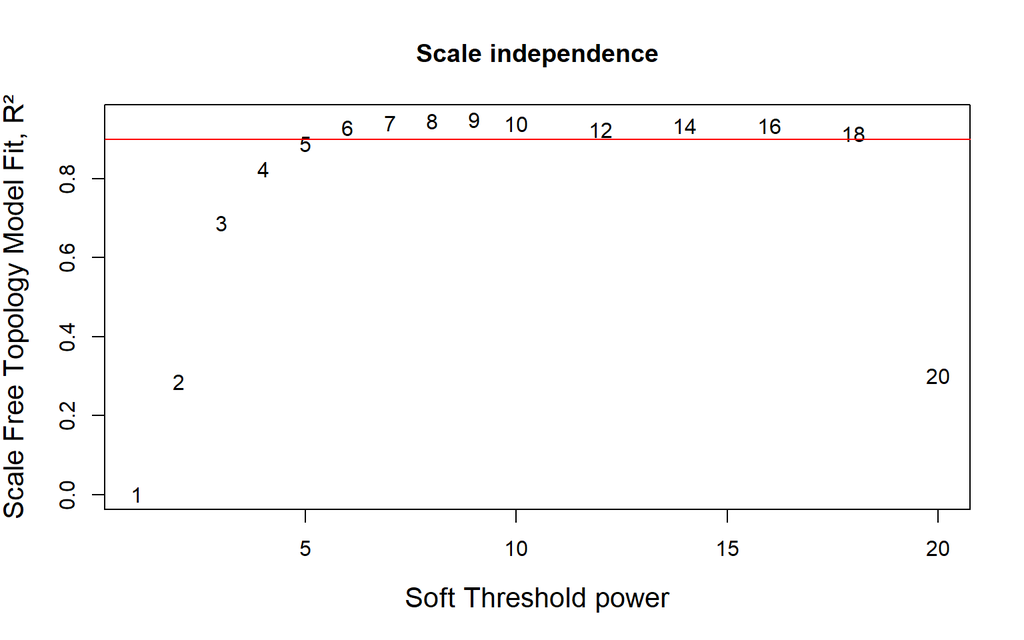

```r
plot(sft$fitIndices[,1], -sign(sft$fitIndices[,3])* sft$fitIndices[,2],
     xlab = "Soft Threshold power", ylab = "Scale Free Topology Model Fit, R²",
     type = "n", main = "Scale independence", cex.lab = 1.3)
text(sft$fitIndices[,1], -sign(sft$fitIndices[,3])* sft$fitIndices[,2], labels = powers, cex = 1, col = "black")
abline(h = 0.90, col = "red")
```

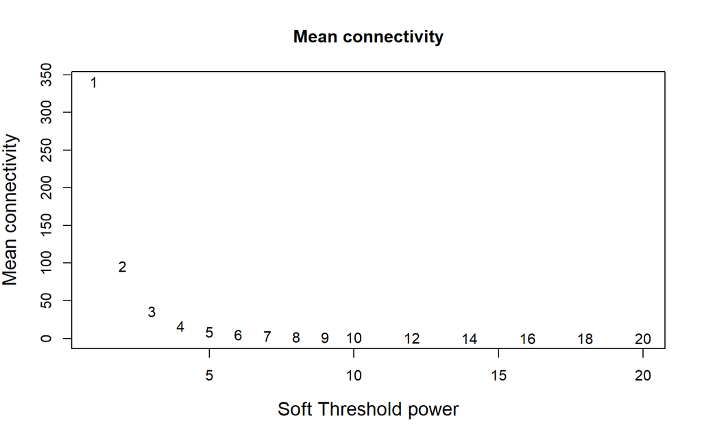

```r
plot(sft$fitIndices[,1], sft$fitIndices[,5],
     xlab = "Soft Threshold power", ylab = "Mean connectivity",
     type = "n", main = "Mean connectivity", cex.lab = 1.3)
text(sft$fitIndices[,1], sft$fitIndices[,5], labels = powers, cex = 1, col = "black")
```

## Similarity matrix construction

**Objective:**choose the power 6 to build the similarity matrix.  
**Commands:** the code calculates the similarity matrix using the **adjacency()** function, passing exprData as the input data and softPower=6 as the power, and then display a subset(5 first rows, 5 first columns) of the similarity matrix.  
**Interpretation:**here we choose the power 6, which is the lowest power for which the scale-free topology fit index reaches 0.90.

```r
softPower <- 6
similarityMat <- adjacency(exprData, power = softPower)
similarityMat[c(1:5), c(1:5)]
```

```
##                  STC2     LOC96610         APOD        FADS2         RPL9
## STC2     1.000000e+00 9.800808e-04 6.282220e-10 1.020088e-03 1.212973e-09
## LOC96610 9.800808e-04 1.000000e+00 8.826956e-06 1.702183e-05 4.049903e-09
## APOD     6.282220e-10 8.826956e-06 1.000000e+00 2.134894e-08 7.213511e-13
## FADS2    1.020088e-03 1.702183e-05 2.134894e-08 1.000000e+00 3.873576e-06
## RPL9     1.212973e-09 4.049903e-09 7.213511e-13 3.873576e-06 1.000000e+00
```

## Topological overlap matrix (TOM)

**Objective:** to built a Topological Overlap Matrix(TOM) that incorporates the level of overlapping between the neighboring of two genes.  
**Commands:** to calculate the TOM (Topological Overlap Matrix) similarity using the precomputed similarity matrix **similarityMat** and stores the result in the **TOM** variable.  
**Outputs:** Topological Overlap Matrix(TOM).  
**Interpretation:** The Similarity matrix describes the similarity between each pair of genes based on correlations. This matrix is next transformed into a Topological Overlap Matrix that incorporates the level of overlapping between the neighboring of two genes.

For instance, genes with high level of similarity are grouped together (value close to 1 in the similarity matrix). If their communities also highly overlap, these two genes will be closer.

```r
TOM <- TOMsimilarity(similarityMat)
```

```
## ..connectivity..
## ..matrix multiplication (system BLAS)..
## ..normalization..
## ..done.
```

**Objective:** align the appropriate row and column names of the **TOM** matrix.  
**Commands:** to align the row and column names of the **TOM** matrix with those of the **similarityMat** matrix and then extracts a submatrix for inspection or analysis.

```r
colnames(TOM) <- colnames(similarityMat)
rownames(TOM) <- rownames(similarityMat)
TOM[c(1:5), c(1:5)]
```

```
##                  STC2     LOC96610         APOD        FADS2         RPL9
## STC2     1.000000e+00 1.409307e-03 1.216776e-04 2.430333e-03 1.172863e-06
## LOC96610 1.409307e-03 1.000000e+00 3.377810e-04 1.925742e-04 1.026022e-06
## APOD     1.216776e-04 3.377810e-04 1.000000e+00 3.177204e-05 3.227948e-07
## FADS2    2.430333e-03 1.925742e-04 3.177204e-05 1.000000e+00 4.802354e-06
## RPL9     1.172863e-06 1.026022e-06 3.227948e-07 4.802354e-06 1.000000e+00
```

**Objective:** to calculate the dissimilarity matrix **dissTOM** from the **TOM** values and then extracts a submatrix for a subset of data.  
**Outputs:** the dissimilarity matrix **dissTOM**.  
**Interpretation:** the TOM is then transformed into a dissimilarity TOM: that means that two genes highly similar have a similarity value close to 0. It allows you to focus on patterns of dissimilarity and separation between entities in your network.

In general, to let the most similar expressed genes to have the smallest distance values which is represented by similarity.

```r
dissTOM <- 1 - TOM
dissTOM[c(1:5), c(1:5)]
```

```
##               STC2  LOC96610      APOD     FADS2      RPL9
## STC2     0.0000000 0.9985907 0.9998783 0.9975697 0.9999988
## LOC96610 0.9985907 0.0000000 0.9996622 0.9998074 0.9999990
## APOD     0.9998783 0.9996622 0.0000000 0.9999682 0.9999997
## FADS2    0.9975697 0.9998074 0.9999682 0.0000000 0.9999952
## RPL9     0.9999988 0.9999990 0.9999997 0.9999952 0.0000000
```

# Module detection

## Clustering

**Objective:** to create a hierarchical cluster tree based on the dissimilarity matrix **dissTOM**.  
**Outputs:** dendrogram of hierarchical clustering on highly co-expressed genes’ groups.  
**Interpretation:** the leaves represent the genes. The dendrogram branches group together densely interconnected and highly co-expressed genes.

Visually, we can identify at least 5 or 6 modules.

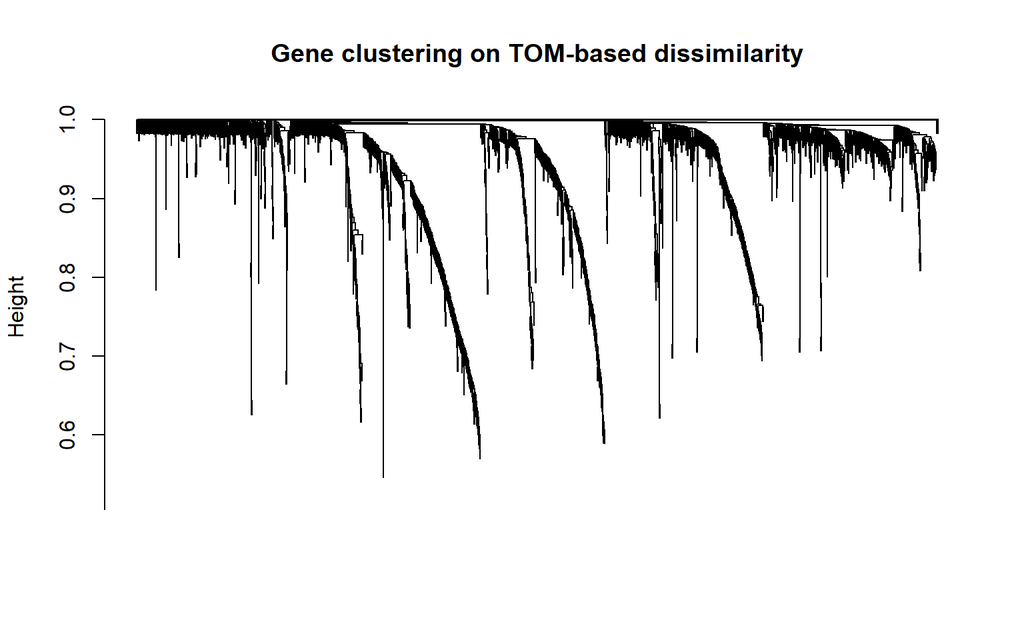

```r
geneTree <- hclust(as.dist(dissTOM), method = "average")
plot(geneTree, xlab = "", sub = "", main = "Gene clustering on TOM-based dissimilarity", labels = FALSE, hang = 0.04)
```

## Module identification

**Objective:** use the Dynamic Tree Cut() function to identify the modules of genes’ group.  
**Commands:** set the minimum module size(minimum number of genes inside a group/module) as 30, then identify the modules.

```r
minModuleSize <- 30
dynamicMods <- cutreeDynamic(dendro = geneTree,
                 distM = dissTOM,
                 deepSplit = 2,
                 pamRespectsDendro = FALSE,
                 minClusterSize = minModuleSize)
```

```
##  ..cutHeight not given, setting it to 0.997  ===>  99% of the (truncated) height range in dendro.
##  ..done.
```

**Objective:** to show the result of module identification, including number of module and the number of genes in each module.  
**Interpretation:** the method identifies 5 modules. The cluster 0 contains the unassigned genes. There is a big module (the first one) with 908 genes.

```r
table(dynamicMods)
```

```
## dynamicMods
##   0   1   2   3   4   5
## 300 908 371 280  89  52
```

**Objective:** to color the modules and show the details after colored.

```r
dynamicColors <- labels2colors(dynamicMods)
table(dynamicColors)
```

```
## dynamicColors
##      blue     brown     green      grey turquoise    yellow
##       371       280        52       300       908        89
```

**Objective:** to display the identification results using a dendrogram and the assigned color.  
**Interpretation:** we can observe the distribution of modules on the tree in terms of color.

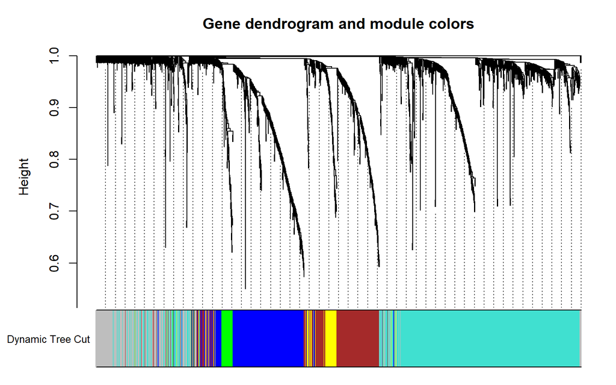

```r
plotDendroAndColors(dendro = geneTree, colors = dynamicColors, groupLabels = "Dynamic Tree Cut",
        dendroLabels = FALSE, hang = 0.03, addGuide = TRUE, guideHang = 0.05,
        main = "Gene dendrogram and module colors")
```

## Merging modules

**Objective:** to calculate the eigengenes of each module. Eigengene is the first principal component of a module (dimension reduction).  
**Commands:** to extract the module eigengenes from the **MEList** and stores them in the **MEs**.  
**Interpretation:** module eigengenes are representative expression profiles for each module and are often used to summarize the expression patterns within a module.

The values of the eigengenes represent the strength of the overall expression pattern within the first principal component.

```r
MEList <- moduleEigengenes(exprData, colors = dynamicColors)
MEs <- MEList$eigengenes
MEs <- orderMEs(MEs)
head(MEs)
```

```
##            MEblue     MEgreen MEturquoise     MEbrown    MEyellow      MEgrey
## A0SH -0.003763839 -0.05955536  0.02312983  0.10465496 -0.01212317 -0.05516091
## A0SJ -0.020917560 -0.02408432  0.01715609  0.02630589  0.06563727 -0.03604684
## A0SK -0.104121719 -0.12921101 -0.09806951 -0.07988094 -0.09619792  0.09957517
## A0SO -0.077953493 -0.06860749 -0.09164466 -0.10106987 -0.05746363  0.04673793
## A04N -0.007276244 -0.03752692  0.04488648  0.05265763  0.01783336  0.03871323
## A04P  0.024766791  0.01468890 -0.08919126 -0.01027211  0.02749866  0.04509383
```

**Objective:**construct the distance matrix between modules.  
**Interpretation:** to calculate correlation between each pair of module (Pearson correlation). If modules are close/similar, the correlation will be closed to 1. We compute a distance between modules based on correlation using (1- correlation).

```r
MEDiss <- 1 - cor(MEs)
head(MEDiss)
```

```
##                   MEblue   MEgreen MEturquoise   MEbrown  MEyellow    MEgrey
## MEblue      4.440892e-16 0.5124083   1.2620744 0.6117870 0.6379130 0.9251374
## MEgreen     5.124083e-01 0.0000000   0.9700988 0.9681992 0.9719671 1.1584903
## MEturquoise 1.262074e+00 0.9700988   0.0000000 0.8456227 0.6656522 1.1214573
## MEbrown     6.117870e-01 0.9681992   0.8456227 0.0000000 0.3500885 1.0340146
## MEyellow    6.379130e-01 0.9719671   0.6656522 0.3500885 0.0000000 0.8944425
## MEgrey      9.251374e-01 1.1584903   1.1214573 1.0340146 0.8944425 0.0000000
```

**Objective:**hierarchical clustering on modules.  
**Interpretation:** to perform a hierarchical clustering using this distance between modules. Authors recommend to merge cluster with a correlation greater than 0.75, hence a distance lower than 0.25. In our case, no modules need to be merged because the modules with a distance lower than 0.25 are all seperated.

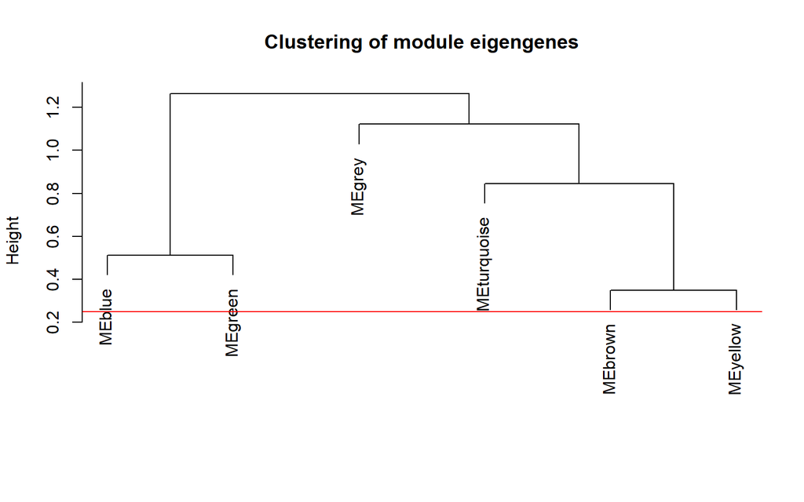

```r
METree <- hclust(as.dist(MEDiss))
MEDissTree <- 0.25
plot(METree, main = "Clustering of module eigengenes", xlab = "", sub = "")
abline(h = MEDissTree, col = "red")
```

# Module characterization

## Association between modules and phenotypic traits

**Objective:** clinical data need to be numerical for the correlation calculation.  
**Data loaded:** clinical data table **clinicalData**.  
**Outputs:** numerical clinical data table **clinicalDataNum**.  
**Interpretation:**we have both categorical and continuous data in clinical data, in order to identify which modules are significantly associated with the clinical metadata we have, we need to first transfer clinical data to be numerical for the correlation calculation.

```r
clinicalDataNum <- clinicalData
clinicalDataNum$AnatomicNeoplasm <- as.numeric(clinicalData$AnatomicNeoplasm)
clinicalDataNum$Gender <- as.numeric(clinicalData$Gender)
clinicalDataNum$VitalStatus <- as.numeric(clinicalData$VitalStatus)
clinicalDataNum$Subtype <- as.numeric(clinicalData$Subtype)
```

**Objective:**to calculate the Pearson correlations between the identified modules and clinical information. P-values are then calculated to find the most significant correlations.  
**Interpretation:**to assesse the correlation between module eigengenes and clinical data, providing both correlation coefficients and their associated p-values to determine the statistical significance of the relationships.

```r
moduleTraitCor <- cor(MEs, clinicalDataNum, use = "p")
moduleTraitPvalue <- corPvalueStudent(moduleTraitCor, nPatients)
```

**Objective:** to build a matrix on the correlation between clinical features and modules.  
**Interpretation:** this code essentially filters out correlations with p-values greater than 0.05, replacing them with zeros in moduleTraitCor and clearing the corresponding text in textMatrix.

```r
textMatrix <- paste(signif(moduleTraitCor, 2), "\n(", signif(moduleTraitPvalue, 1), ")", sep = "")
dim(textMatrix) <- dim(moduleTraitCor)
colnames(textMatrix) <- colnames(moduleTraitCor)
rownames(textMatrix) <- rownames(moduleTraitCor)
for(r in row.names(moduleTraitCor)){
  for(c in colnames(moduleTraitCor)){
    if(moduleTraitPvalue[r, c] > 0.05){
      moduleTraitCor[r, c] <- 0
      textMatrix[r, c] <- ""
      }
  }
}
```

**Objective:**to draw a heatmap on the Module-trait relationship based on matrix **moduleTraitCor**.  
**Interpretation:**  
Legend:  
White: no correlation  
Darkpurple: strong positive correlation  
Darkgreen: strong negative correlation

There is no correlation between modules and gender. But, we can see a strong correlation between the turquoise module and the breast cancer subtype.

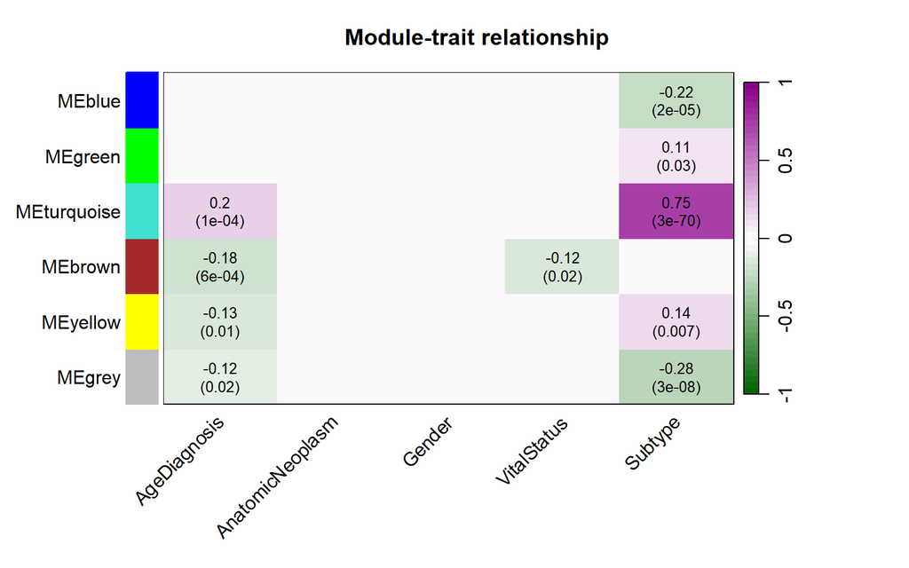

```r
labeledHeatmap(Matrix = moduleTraitCor,
   xLabels = names(clinicalDataNum),
   yLabels = names(MEs),
   ySymbols = names(MEs),
   colorLabels = FALSE,
   colors =  colorRampPalette(c("darkgreen", "white", "darkmagenta"))(50),
   textMatrix = textMatrix,
   setStdMargins = TRUE,
   cex.text = 0.8,
   zlim = c(-1, 1),
   main = "Module-trait relationship")
```

## Gene relationship to traits and modules

**Objective:** to build the **subtype** data frame to concentrate on subtype as the trait of interest.  
**Additional specific informations:**  
Two measurements are calculated to quantify the association between genes and our trait of interest (here cancer subtypes) and the similarity of all genes to every module.

These two measures are:  
Gene Significance (GS): correlation between the gene and the selected trait  
Module Membership (MM): correlation between the module eigengene and the gene expression profile

```r
subtype = as.data.frame(clinicalDataNum$Subtype)
names(subtype) <- "subtype"
```

**Objective:**to calculate the Module Membership (MM) using a Pearson correlation between genes and identified modules. P-values are calculation for those correlations.  
**Commands:** see comments in the chunk.

```r
modNames <- substring(names(MEs), 3) # Get module names
geneModuleMembership <- as.data.frame(cor(exprData, MEs, use = "p"))# Calculate gene module membership
MMPvalue <- as.data.frame(corPvalueStudent(as.matrix(geneModuleMembership), nPatients))# Calculate p-values for gene module membership
# Name the results
names(geneModuleMembership) <- paste("MM", modNames, sep = "")
names(MMPvalue) <- paste("p.MM", modNames, sep = "")
```

**Objective:**to calculate the Gene Significance (GS) for every genes. A Pearson correlation is calculated between genes and each cancer subtype. Then, a p-value is calculated for those correlations.  
**Commands:** see comments in the chunk.  
**additional specific informations:**  
A gene with a high MM correlation means a high membership to this module. A gene with a high GS correlation means a high association with the selected trait.

These two measures help to identify genes that have a high significance for cancer subtypes as well as high module membership in interesting modules.

```r
geneTraitSignificance <- as.data.frame(cor(exprData, subtype, use = "p")) # to calculate gene subtype significance, which represents the correlation between genes and subtype. It creates a data frame containing the correlations between each gene and subtype.
GSPvalue <- as.data.frame(corPvalueStudent(as.matrix(geneTraitSignificance), nPatients)) #  Calculate p-values for gene subtype significance
# Name the results
names(geneTraitSignificance) <- paste("GS", names(subtype), sep = "")
names(GSPvalue) <- paste("p.GS", names(subtype), sep = "")
```

**Objective:** to draw a scatterplot of GS vs. MM in the turquoise module.  
**Commands:** see comments in the chunk.  
**Interpretation:** GS and MM are highly correlated: genes highly significantly associated with subtype are often also the most important (central) elements of turquoise module associated with the subtype.

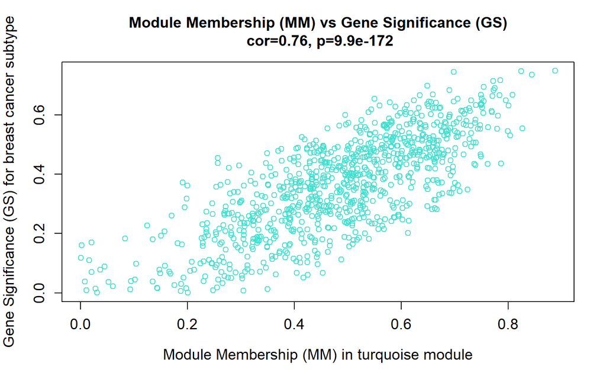

```r
module <- "turquoise" # Define the module of interest as turquoise
column <- match(module, modNames) # Find the column corresponding to the module in the data
moduleGenes <- dynamicColors == module # Select genes belonging to module turquoise
# Create the scatterplot of GS vs. MM in the turquoise module
verboseScatterplot(abs(geneModuleMembership[moduleGenes, column]),
       abs(geneTraitSignificance[moduleGenes, 1]),
       xlab = paste("Module Membership (MM) in", module, "module"),
       ylab = "Gene Significance (GS) for breast cancer subtype",
       main = paste("Module Membership (MM) vs Gene Significance (GS)\n"),
       cex.main = 1.2, cex.lab = 1.2, cex.axis = 1.2, col = module)
```

**Objective:**to create and to save a CSV file that summarizes all results. Modules are ordered by their significance for subtype.  
**Commands:** see comments in the chunk.  
**Interpretation:** to create and organize a data frame containing gene information, including gene symbols, module colors, gene subtype significance, p-values, module membership values, and corresponding p-values. Finally, it writes this information to a CSV file.

```r
# Create a data frame with gene information
geneInfo0 <- data.frame(geneSymbol = row.names(geneTraitSignificance),
                        moduleColor = dynamicColors,
                        geneTraitSignificance,
                        GSPvalue)
# Order modules based on their correlation with subtype
modOrder <- order(-abs(cor(MEs, subtype, use = "p")))
# Iterate through modules
for(mod in 1:ncol(geneModuleMembership))
{
oldNames <- names(geneInfo0)
# Add module membership values and p-values to the data frame
geneInfo0 <- data.frame(geneInfo0, geneModuleMembership[, modOrder[mod]],
              MMPvalue[, modOrder[mod]])
# Update column names with module-specific labels
names(geneInfo0) <- c(oldNames,
            paste("MM.", modNames[modOrder[mod]], sep = ""),
            paste("p.MM", modNames[modOrder[mod]], sep = ""))
}
# Order genes based on module color and gene trait significance
geneOrder <- order(geneInfo0$moduleColor, -abs(geneInfo0$p.GSsubtype))
# Reorganize the gene information based on the specified order
geneInfo <- geneInfo0[geneOrder, ]
# Write the gene information to a CSV file
write.csv(x = geneInfo, file = "02_Results/WGCNA_genesInfo.csv", quote = FALSE)
```

## Enrichment analysis

We perform this analysis directly in Cytoscape.

## Turquoise module

**Objective:**heatmap of gene expression based on Subtype in turquoise module.  
**Commands:** see comments in the chunk.  
**Interpretation:**：the turquoise module is related to breast cancer subtypes. It could be interesting to look for the expression data of the genes inside this module.

On the heatmap, patients are grouped into 4 clusters based on the expression data. Colors represent the patient subtypes.

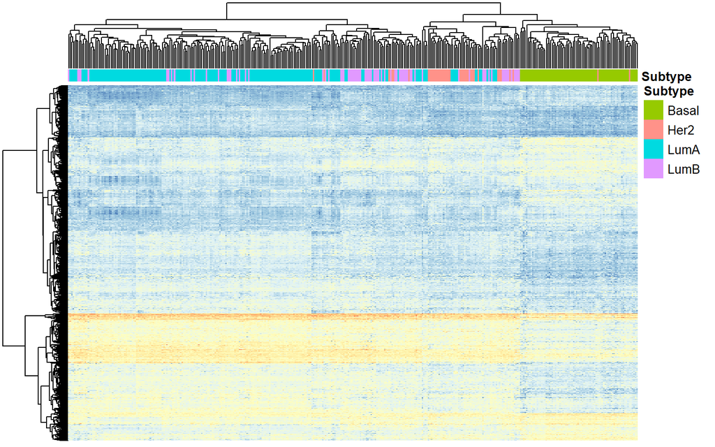

```r
# Select genes belonging to the "turquoise" module
selectedGenes <- geneInfo[geneInfo$moduleColor == "turquoise", ]$geneSymbol
# Extract gene expression data for "turquoise" module genes
turquoiseExprData <- t(exprData[,selectedGenes])
# First heatmap without legend
pheatmap(turquoiseExprData, show_rownames = FALSE, show_colnames = FALSE, annotation_col = clinicalData["Subtype"],
         legend = FALSE)
```

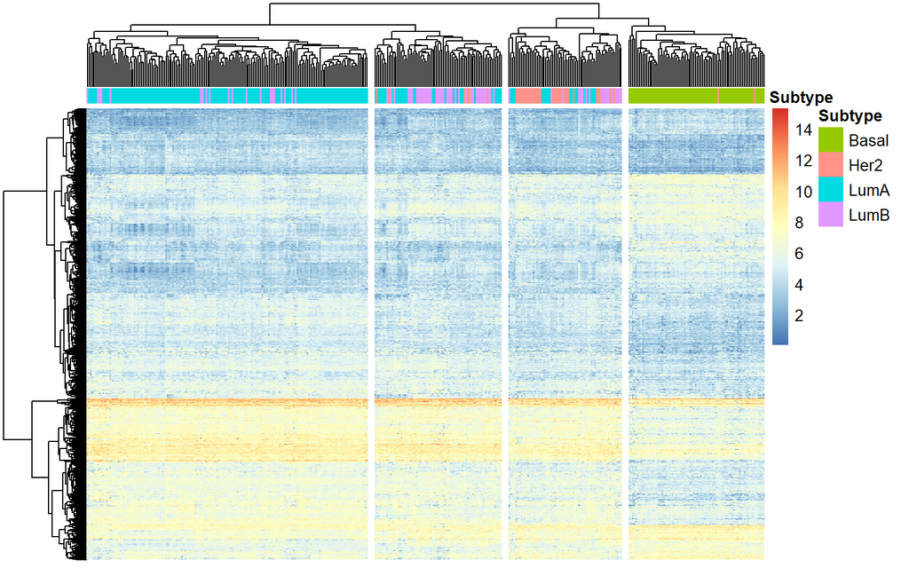

```r
# Second heatmap with clustering (cutree_cols = 4)
heatmap <- pheatmap(turquoiseExprData, show_rownames = FALSE, show_colnames = FALSE,
                    annotation_col = clinicalData["Subtype"], cutree_cols = 4)
```

**Objective:** to perform clustering of rows (genes) in the heatmap and to write the cluster assignments to a text file.  
**Interpretation:**：Data are split into 4 groups and results are saved into a file.

```r
heat_cluster <- as.data.frame(cutree(heatmap$tree_row, k = 4))
write.table(x = heat_cluster, file = "02_Results/TurquoiseModule_clusters.txt", quote = FALSE, sep = "\t", col.names = FALSE, row.names = TRUE)
```

# Network visualization

## Eigengenes network

**Objective:** to study the relationship between the identified modules, to see how the subtype fit into eigengenes network.  
**Interpretation:**：we found that the turquoise module is highly correlated to the subtypes, while no other mudule is correlated notably to the subtypes.

Module brown and module yellow have strong correlation and both of them have negative correlation with AgeDiagnosis(Figure 7.1 Module-trait relationship).

Module green and module blue have strong correlation and both of them have no correlation with AgeDiagnosis(Figure 7.1 Module-trait relationship).

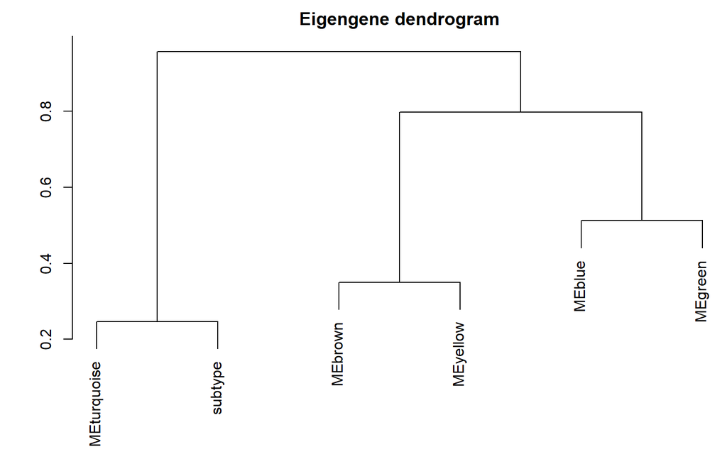

```r
MEs <- moduleEigengenes(exprData, dynamicColors)$eigengenes
MET <- orderMEs(cbind(MEs, subtype))
plotEigengeneNetworks(MET, "Eigengene dendrogram", marDendro = c(0,4,2,0), plotHeatmaps =  FALSE)
```

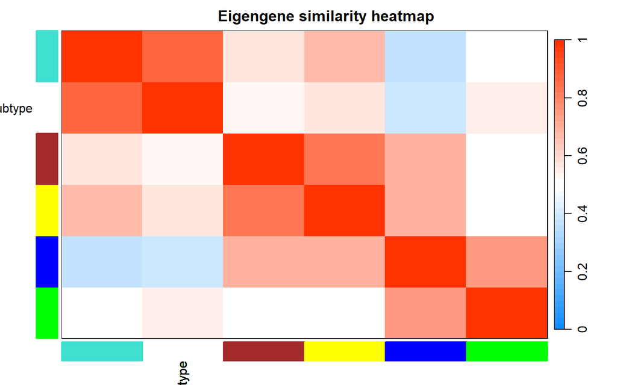

```r
plotEigengeneNetworks(MET, "Eigengene similarity heatmap", marHeatmap = c(3,4,2,2), plotDendrograms = FALSE, xLabelsAngle = 90)
```

## Gene networks

**Objective:**to creat a heatmap on the TOM similarity between each pair of genes to visualize the weighted network.  
**Interpretation:**to make moderately strong connections more visible, TOM is transformed using a power and then the diagonal are set to NA.

Each row and column of the heatmap correspond to a single gene. Light colors represents low similarity and darker colors higher similarity. Blocks of darker colors along the diagonal are the modules. The gene dendogram and module assignment are shown along the left side and the top.

This plot visualizes the network structure of all genes based on their topological overlap, with genes grouped into modules represented by dynamicColors. The plot provides insights into gene co-expression patterns and module structure within the network.

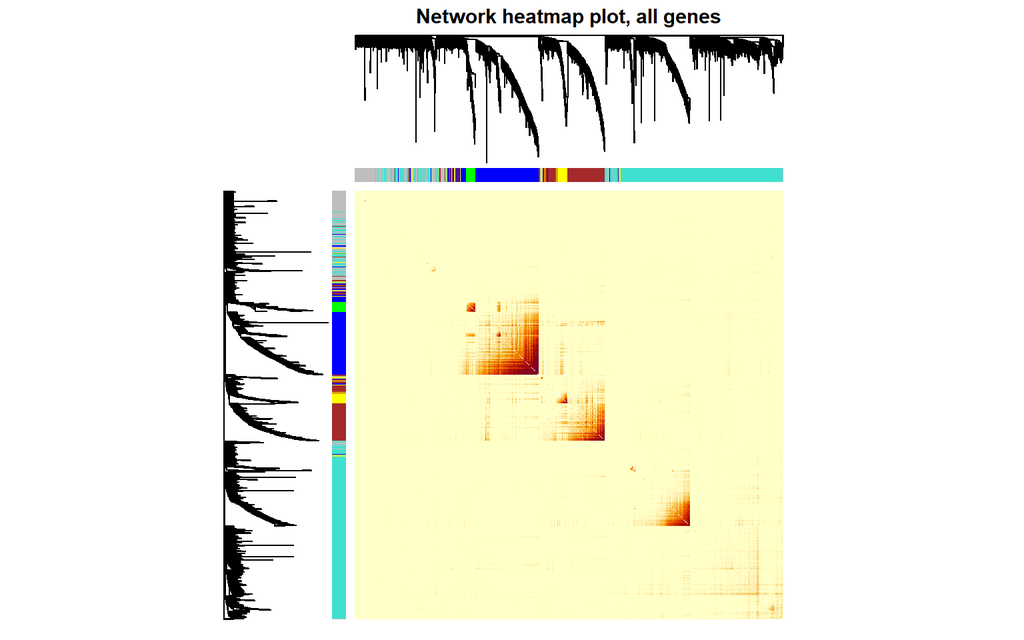

```r
plotTOM <- -dissTOM^7
diag(plotTOM) <- NA
TOMplot(plotTOM, geneTree, dynamicColors, main = "Network heatmap plot, all genes")
```

**Objective:**to display only the heatmap for the turquoise module.

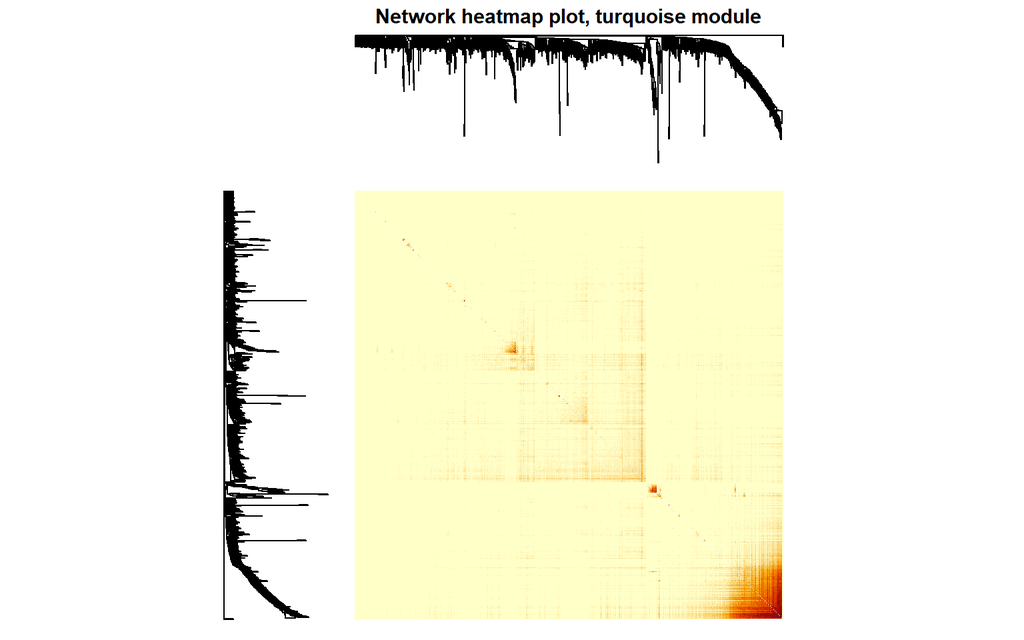

```r
selectedGenes <- geneInfo[geneInfo$moduleColor == "turquoise", ]$geneSymbol
selectTOM <- dissTOM[selectedGenes, selectedGenes]
selectTree <- hclust(as.dist(selectTOM), method = "average")
plotDiss <- -selectTOM^7
diag(plotDiss) <- NA
TOMplot(plotDiss, selectTree, main = "Network heatmap plot, turquoise module")
```

## Cytoscape

**Objective:**to extract the whole network into an edge file for Cytoscape to build the network.build the network.

```r
cyt <- exportNetworkToCytoscape(TOM,
                    edgeFile = "02_Results/CytoscapeInput_edges.txt",
                    weighted = TRUE,
                    threshold = 0.05,
                    nodeNames = colnames(exprData))
```